# More dplyr

June 10, 2015

## Using the packages tidyr, dplyr

During a ten week sensory experiment, 12 individuals were asked to assess taste of french fries on several scales (how potato-y, buttery, grassy, rancid, paint-y do the fries taste?)

French fries were fried in one of three different oils, and each week individuals had to assess six batches of french fries (all three oils, replicated twice)

## This format is not ideal for data analysis

What code would be needed to plot each of the ratings over time as a different color?

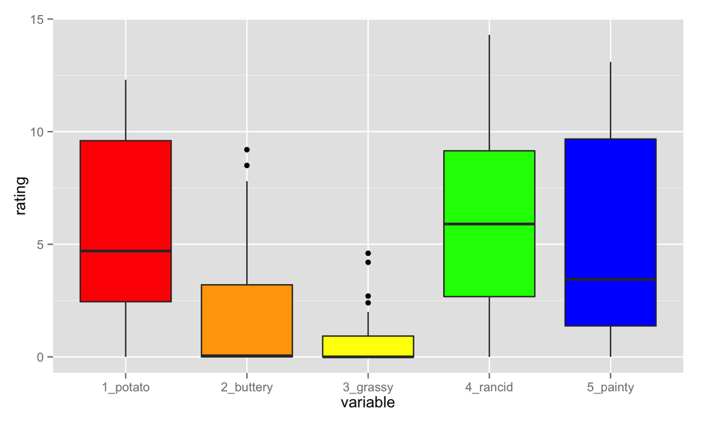

## What we have and what we want

We want to change this **wide format**:

[figure not shown]

## Gathering

- When gathering, you need to specify the **keys** (identifiers) and the **values** (measures).

Keys/Identifiers:

- Identify a record (must be unique)
- Example: Indices on an random variable
- Fixed by design of experiment (known in advance)
- May be single or composite (may have one or more variables)

Values/Measures:

- Collected during the experiment (not known in advance)
- Usually numeric quantities

## Gathering the French Fry Data

```r
french_fries_long <- gather(french_fries, key = variable, value = rating, potato:painty)

head(french_fries_long)
```

```
##   time treatment subject rep variable rating
## 1    1         1       3   1   potato    2.9
## 2    1         1       3   2   potato   14.0
## 3    1         1      10   1   potato   11.0
## 4    1         1      10   2   potato    9.9
## 5    1         1      15   1   potato    1.2
## 6    1         1      15   2   potato    8.8
```

## Let's Reconstruct our Plot

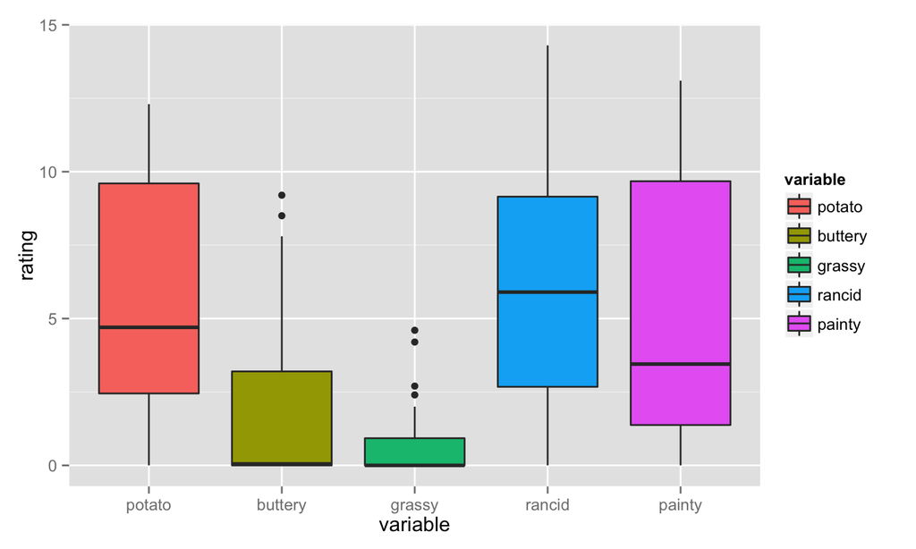

```r
french_fries_long_sub <- french_fries_long[
  french_fries_long$time == 10,]

qplot(variable, rating, data = french_fries_long_sub, fill = variable, geom = "boxplot")
```

## Long to Wide

In certain applications, we may wish to take a long dataset and convert it to a wide dataset (Perhaps displaying in a table).

```r
head(french_fries_long)
```

```
##   time treatment subject rep variable rating
## 1    1         1       3   1   potato    2.9
## 2    1         1       3   2   potato   14.0
## 3    1         1      10   1   potato   11.0
## 4    1         1      10   2   potato    9.9
## 5    1         1      15   1   potato    1.2
## 6    1         1      15   2   potato    8.8
```

## Spread

We use the **spread** function from tidyr to do this:

```r
french_fries_wide <- spread(french_fries_long, key = variable, value = rating)

head(french_fries_wide)
```

```
##   time treatment subject rep potato buttery grassy rancid painty
## 1    1         1       3   1    2.9     0.0    0.0    0.0    5.5
## 2    1         1       3   2   14.0     0.0    0.0    1.1    0.0
## 3    1         1      10   1   11.0     6.4    0.0    0.0    0.0
## 4    1         1      10   2    9.9     5.9    2.9    2.2    0.0
## 5    1         1      15   1    1.2     0.1    0.0    1.1    5.1
## 6    1         1      15   2    8.8     3.0    3.6    1.5    2.3
```

## YOUR TURN

1. Read in the billboard top 100 music data, which contains N'Sync and Backstreet Boys songs that entered the billboard charts in the year 2000

   ```r
   billboard <- read.csv("http://heike.github.io/rwrks/03a-r-format/data/billboard.csv")
   ```

2. Use `tidyr` to convert this data into a long format appropriate for plotting a time series (date on the x axis, chart position on the y axis)
1. Use `ggplot2` to create this time series plot:

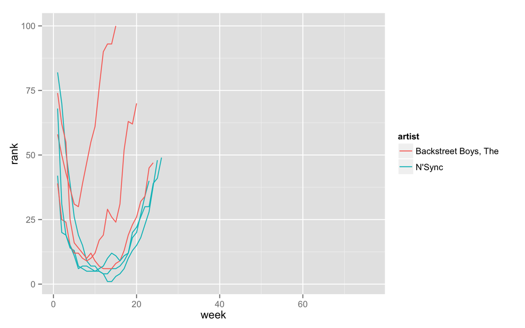

## The Split-Apply-Combine Approach

- *Split* a dataset into many smaller sub-datasets
- *Apply* some function to each sub-dataset to compute a result
- *Combine* the results of the function calls into a one dataset

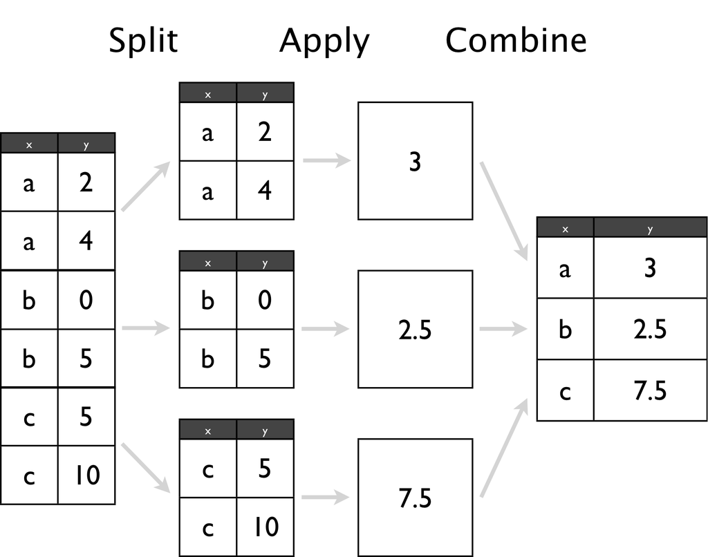

## Split-Apply-Combine in dplyr

```r
library(dplyr)

french_fries_split <- group_by(french_fries_long, variable) # SPLIT
french_fries_apply <- summarise(french_fries_split, rating = mean(rating, na.rm = TRUE)) # APPLY + COMBINE
french_fries_apply
```

```
## Source: local data frame [5 x 2]
##
##   variable    rating
## 1   potato 6.9525180
## 2  buttery 1.8236994
## 3   grassy 0.6641727
## 4   rancid 3.8522302
## 5   painty 2.5217579
```

## The pipe operator

- dplyr allows us to chain together these data analysis tasks using the `%>%` (pipe) operator
- `x %>% f(y)` is shorthand for `f(x, y)`
- Example:

```r
french_fries %>%
    gather(key = variable, value = rating, potato:painty) %>%
    group_by(variable) %>%
    summarise(rating = mean(rating, na.rm = TRUE))
```

```
## Source: local data frame [5 x 2]
##
##   variable    rating
## 1   potato 6.9525180
## 2  buttery 1.8236994
## 3   grassy 0.6641727
## 4   rancid 3.8522302
## 5   painty 2.5217579
```

## dplyr verbs

There are five primary dplyr **verbs**, representing distinct data analysis tasks:

- Filter: Remove the rows of a data frame, producing subsets
- Arrange: Reorder the rows of a data frame
- Select: Select particular columns of a data frame
- Mutate: Add new columns that are functions of existing columns
- Summarise: Create collapsed summaries of a data frame

## Filter

```r
french_fries %>%
    filter(subject == 3, time == 1)
```

```
##   time treatment subject rep potato buttery grassy rancid painty
## 1    1         1       3   1    2.9     0.0    0.0    0.0    5.5
## 2    1         1       3   2   14.0     0.0    0.0    1.1    0.0
## 3    1         2       3   1   13.9     0.0    0.0    3.9    0.0
## 4    1         2       3   2   13.4     0.1    0.0    1.5    0.0
## 5    1         3       3   1   14.1     0.0    0.0    1.1    0.0
## 6    1         3       3   2    9.5     0.0    0.6    2.8    0.0
```

## Arrange

```r
french_fries %>%
    arrange(desc(rancid)) %>%
    head
```

```
##   time treatment subject rep potato buttery grassy rancid painty
## 1    9         2      51   1    7.3     2.3      0   14.9    0.1
## 2   10         1      86   2    0.7     0.0      0   14.3   13.1
## 3    5         2      63   1    4.4     0.0      0   13.8    0.6
## 4    9         2      63   1    1.8     0.0      0   13.7   12.3
## 5    5         2      19   2    5.5     4.7      0   13.4    4.6
## 6    4         3      63   1    5.6     0.0      0   13.3    4.4
```

## Select

```r
french_fries %>%
    select(time, treatment, subject, rep, potato) %>%
    head
```

```
##    time treatment subject rep potato
## 61    1         1       3   1    2.9
## 25    1         1       3   2   14.0
## 62    1         1      10   1   11.0
## 26    1         1      10   2    9.9
## 63    1         1      15   1    1.2
## 27    1         1      15   2    8.8
```

## Mutate

```r
french_fries %>%
    mutate(rancid2 = rancid^2) %>%
    head
```

```
##   time treatment subject rep potato buttery grassy rancid painty rancid2
## 1    1         1       3   1    2.9     0.0    0.0    0.0    5.5    0.00
## 2    1         1       3   2   14.0     0.0    0.0    1.1    0.0    1.21
## 3    1         1      10   1   11.0     6.4    0.0    0.0    0.0    0.00
## 4    1         1      10   2    9.9     5.9    2.9    2.2    0.0    4.84
## 5    1         1      15   1    1.2     0.1    0.0    1.1    5.1    1.21
## 6    1         1      15   2    8.8     3.0    3.6    1.5    2.3    2.25
```

## Summarise

```r
french_fries %>%
    group_by(time, treatment) %>%
    summarise(mean_rancid = mean(rancid), sd_rancid = sd(rancid))
```

```
## Source: local data frame [30 x 4]
## Groups: time
##
##    time treatment mean_rancid sd_rancid
## 1     1         1    2.758333  3.212870
## 2     1         2    1.716667  2.714801
## 3     1         3    2.600000  3.202037
## 4     2         1    3.900000  4.374730
## 5     2         2    2.141667  3.117540
## 6     2         3    2.495833  3.378767
## 7     3         1    4.650000  3.933358
## 8     3         2    2.895833  3.773532
## 9     3         3    3.600000  3.592867
## 10    4         1    2.079167  2.394737
## ..  ...       ...         ...       ...
```

## YOUR TURN

Read in the flights data:

```r
flights <- read.csv("http://heike.github.io/rwrks/03a-r-format/data/flights.csv")
```

This dataset contains information on over 300,000 flights that departed from New York City in the year 2013.

1. Using dplyr and the pipe operator, create a data frame consisting of the average arrival delay (`arr_delay`) based on the destination airport (`dest`). Sort this data frame in descending order, so the destination airport with the largest delay is first.
2. Find out the most used airports for each airline carrier.

## Dates and Times

Dates are deceptively hard to work with in R.

**Example**: 02/05/2012. Is it February 5th, or May 2nd?

Other things are difficult too:

- Time zones
- POSIXct format in base R is challenging

The **lubridate** package helps tackle some of these issues.

## Basic Lubridate Use

```r
library(lubridate)

now()
today()
now() + hours(4)
today() - days(2)
```

```
## [1] "2015-06-10 15:28:30 CDT"
## [1] "2015-06-10"
## [1] "2015-06-10 19:28:30 CDT"
## [1] "2015-06-08"
```

## Parsing Dates

```r
ymd("2013-05-14")
mdy("05/14/2013")
dmy("14052013")
ymd_hms("2013:05:14 14:50:30", tz = "America/Chicago")
```

```
## [1] "2013-05-14 UTC"
## [1] "2013-05-14 UTC"
## [1] "2013-05-14 UTC"
## [1] "2013-05-14 14:50:30 CDT"
```

## YOUR TURN

1. Using the `flights` data, create a new column Date using lubridate. You will need to paste together the columns year, month, and day in order to do this. See the `paste` function.
2. Use dplyr to calculate the average departure delay for each date.
3. Plot a time series of the date versus the average departure delay

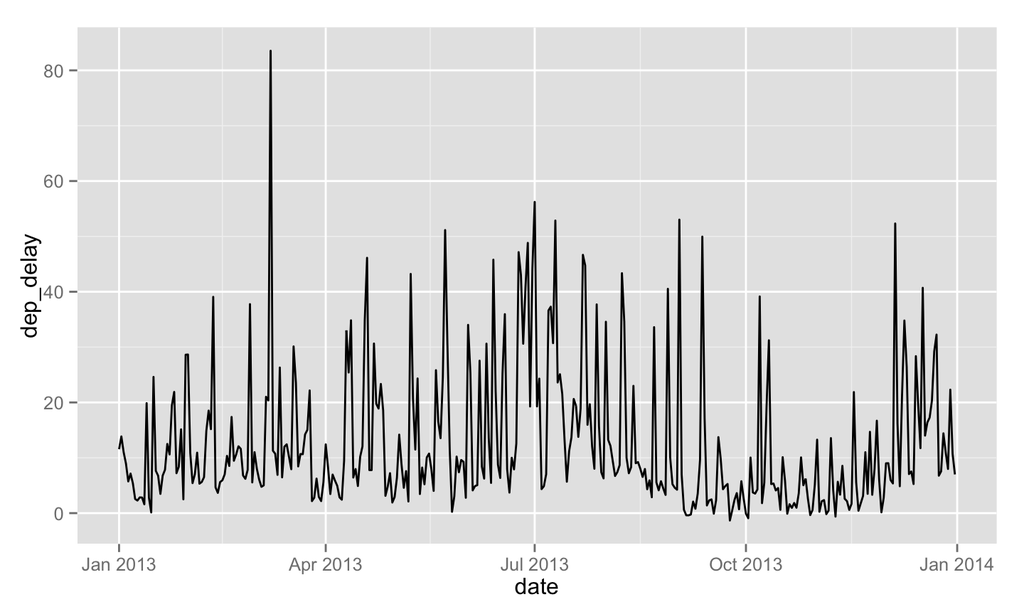